# LEPlmer2021: Demonstracija analize

Dušica Filipović Đurđević

15. oktobar 2021.

# Za početak, učitaćemo potrebne pakete

```r
require(rms)
require(lme4)
require(languageR)
require(multcomp)
require(lsmeans)
require(multcompView)
require(pbkrtest)
require(lmerTest)
require(randomForest)
require(party)
require(gbm)
require(randomForest)
require(party)
require(MASS)
require(car)
require(mgcv)
require(itsadug)
require(methods)
require(effects)
require(RePsychLing)
require(knitr)
require(broom)
```

# potom proverimo sta nam je radni direktorijum

```r
getwd()
```

```
## [1] "C:/Sam/Dokumenti/Obuke/LEPlmer2021"
```

- ako nije onaj koji zelimo, onda podesimo da bude takav (najzgodnije je da to bude onaj u kojem se nalazi fajl sa podacima)

```r
setwd("C:/Sam/Dokumenti/Obuke/LEPlmer2021")
```

- da proverimo da li smo uspeli

```r
getwd()
```

```
## [1] "C:/Sam/Dokumenti/Obuke/LEPlmer2021"
```

# Potom učitamo i razgledamo podatke

```r
dat=read.table("FilipovicDurdevic.Kostic.SerbianPolysemy_short.txt",sep="\t",T)

dim(dat)
```

```
## [1] 4650   17
```

```r
colnames(dat)
```

```
##  [1] "Participant"  "Trial_number" "Trial_order"  "Error_code"   "RT"
##  [6] "Word"         "len"          "fam"          "conc"         "freko"
## [11] "ort"          "N"            "H"            "Hrel"         "T"
## [16] "pp1"          "pp1_pp2"
```

```r
head(dat)
```

```
##     Participant Trial_number Trial_order Error_code  RT   Word len  fam conc
## 1 Participant_1            1          42          1 641   SILA   4 6.53 2.26
## 2 Participant_1            2         199          1 661  KLJU^   5 6.83 6.57
## 3 Participant_1            3          48          1 771  STOPA   5 5.94 4.52
## 4 Participant_1            4         197          1 681  POJAS   5 6.35 5.86
## 5 Participant_1            5          43          1 580 STEPEN   6 5.94 2.35
## 6 Participant_1            6         291          1 540  JEZIK   5 6.88 5.24
##   freko ort  N        H      Hrel         T       pp1    pp1_pp2
## 1   365  13 23 3.986627 0.8813027 0.1186973 0.1571429 0.04285714
## 2   106   1 11 2.993384 0.8652820 0.1347180 0.2608696 0.10144928
## 3   379   6  8 2.615237 0.8717458 0.1282542 0.2641509 0.01886793
## 4   111   2 16 3.521572 0.8803931 0.1196069 0.1875000 0.03125000
## 5   106   1 11 2.861359 0.8271183 0.1728817 0.2407407 0.00000000
## 6   537   2 14 3.094742 0.8128325 0.1871675 0.2500000 0.03571429
```

```r
str(dat)
```

```
## 'data.frame':    4650 obs. of  17 variables:
##  $ Participant : chr  "Participant_1" "Participant_1" "Participant_1" "Participant_1" ...
##  $ Trial_number: int  1 2 3 4 5 6 7 8 9 10 ...
##  $ Trial_order : int  42 199 48 197 43 291 84 201 122 234 ...
##  $ Error_code  : int  1 1 1 1 1 1 1 1 1 1 ...
##  $ RT          : int  641 661 771 681 580 540 611 901 781 571 ...
##  $ Word        : chr  "SILA" "KLJU^" "STOPA" "POJAS" ...
##  $ len         : int  4 5 5 5 6 5 5 6 5 5 ...
##  $ fam         : num  6.53 6.83 5.94 6.35 5.94 6.88 6.71 6.74 6.31 6.74 ...
##  $ conc        : num  2.26 6.57 4.52 5.86 2.35 5.24 5.7 4.81 6.43 6.24 ...
##  $ freko       : int  365 106 379 111 106 537 274 226 111 719 ...
##  $ ort         : int  13 1 6 2 1 2 0 5 1 2 ...
##  $ N           : int  23 11 8 16 11 14 14 34 11 18 ...
##  $ H           : num  3.99 2.99 2.62 3.52 2.86 ...
##  $ Hrel        : num  0.881 0.865 0.872 0.88 0.827 ...
##  $ T           : num  0.119 0.135 0.128 0.12 0.173 ...
##  $ pp1         : num  0.157 0.261 0.264 0.188 0.241 ...
##  $ pp1_pp2     : num  0.0429 0.1014 0.0189 0.0312 0 ...
```

# ja volim da ono što će mi biti kategorijalni prediktor, odmah stavim u odgovarajući format

```r
dat$Participant = as.factor(dat$Participant)
dat$Word = as.factor(dat$Word)
```

- pogledamo ponovo

```r
str(dat)
```

```
## 'data.frame':    4650 obs. of  17 variables:
##  $ Participant : Factor w/ 31 levels "Participant_1",..: 1 1 1 1 1 1 1 1 1 1 ...
##  $ Trial_number: int  1 2 3 4 5 6 7 8 9 10 ...
##  $ Trial_order : int  42 199 48 197 43 291 84 201 122 234 ...
##  $ Error_code  : int  1 1 1 1 1 1 1 1 1 1 ...
##  $ RT          : int  641 661 771 681 580 540 611 901 781 571 ...
##  $ Word        : Factor w/ 150 levels "?AVO","]ELIJA",..: 112 36 124 86 123 33 101 52 48 139 ...
##  $ len         : int  4 5 5 5 6 5 5 6 5 5 ...
##  $ fam         : num  6.53 6.83 5.94 6.35 5.94 6.88 6.71 6.74 6.31 6.74 ...
##  $ conc        : num  2.26 6.57 4.52 5.86 2.35 5.24 5.7 4.81 6.43 6.24 ...
##  $ freko       : int  365 106 379 111 106 537 274 226 111 719 ...
##  $ ort         : int  13 1 6 2 1 2 0 5 1 2 ...
##  $ N           : int  23 11 8 16 11 14 14 34 11 18 ...
##  $ H           : num  3.99 2.99 2.62 3.52 2.86 ...
##  $ Hrel        : num  0.881 0.865 0.872 0.88 0.827 ...
##  $ T           : num  0.119 0.135 0.128 0.12 0.173 ...
##  $ pp1         : num  0.157 0.261 0.264 0.188 0.241 ...
##  $ pp1_pp2     : num  0.0429 0.1014 0.0189 0.0312 0 ...
```

# Proverimo da li ima ispitanika koji su pravili previše grešaka

```r
sort(tapply(dat$Error_code, dat$Participant, sum)/150)
```

```
## Participant_57 Participant_13 Participant_17  Participant_6 Participant_20
##      0.7333333      0.8466667      0.8533333      0.9266667      0.9333333
## Participant_21 Participant_16 Participant_19 Participant_22 Participant_24
##      0.9466667      0.9533333      0.9533333      0.9533333      0.9533333
## Participant_26 Participant_18  Participant_8 Participant_11 Participant_27
##      0.9533333      0.9600000      0.9600000      0.9666667      0.9666667
##  Participant_3 Participant_30  Participant_5  Participant_9 Participant_12
##      0.9666667      0.9666667      0.9666667      0.9666667      0.9733333
## Participant_28  Participant_1 Participant_10  Participant_2 Participant_23
##      0.9733333      0.9800000      0.9800000      0.9800000      0.9800000
##  Participant_4  Participant_7 Participant_15 Participant_25 Participant_14
##      0.9800000      0.9800000      0.9866667      0.9866667      0.9933333
## Participant_29
##      0.9933333
```

# na osnovu toga isključimo jednog ispitanika

```r
dat=dat[dat$Participant!="Participant_57",]

dim(dat)
```

```
## [1] 4500   17
```

# Proverimo da li ima reči sa velikim brojem grešaka

```r
sort(tapply(dat$Error_code, dat$Word, sum)/30)
```

```
##     PISAK    PATENT     SFERA     REBRO     BERBA     MEHUR     PEŠAK     GLUMA
## 0.5000000 0.7333333 0.7333333 0.7666667 0.8000000 0.8333333 0.8333333 0.8666667
##    LINIJA     POLET      TEZA     BRADA    CIKLUS     GRA?A     IZLET     KANAL
## 0.8666667 0.8666667 0.8666667 0.9000000 0.9000000 0.9000000 0.9000000 0.9000000
##    KOMORA      KURS     OKLOP      PLOD    PROFIL      SLOJ    BALKON     CREVO
## 0.9000000 0.9000000 0.9000000 0.9000000 0.9000000 0.9000000 0.9333333 0.9333333
##    DVOJKA     GRUPA      GUMA      KLUB     KOREN     LANAC      LOZA      MOST
## 0.9333333 0.9333333 0.9333333 0.9333333 0.9333333 0.9333333 0.9333333 0.9333333
##      OBIM     ORGAN     PESAK      SKOK      STAV     STRUK     TEZGA     VRE]A
## 0.9333333 0.9333333 0.9333333 0.9333333 0.9333333 0.9333333 0.9333333 0.9333333
##     ZGLOB      ?AVO      ^VOR     ALBUM     BALON     GRUDI     IGRA^     IZBOR
## 0.9333333 0.9666667 0.9666667 0.9666667 0.9666667 0.9666667 0.9666667 0.9666667
##     IZVOR     KAPAK     KLJU^     KLJUN     KLUPA     KOLA^    KORICA     KRUNA
## 0.9666667 0.9666667 0.9666667 0.9666667 0.9666667 0.9666667 0.9666667 0.9666667
##     MARKA      MASA     MINUT     MOTIV    OBLAST     OBLIK    OBRADA     OBRU^
## 0.9666667 0.9666667 0.9666667 0.9666667 0.9666667 0.9666667 0.9666667 0.9666667
##    PLATNO     PLO^A    POJAVA    POKRET    POSKOK     POŠTA     POTEZ     PRUGA
## 0.9666667 0.9666667 0.9666667 0.9666667 0.9666667 0.9666667 0.9666667 0.9666667
##    RADNJA     SCENA    SKAKA^     STENA    STEPEN     TEKST    TERMIN     TRAKA
## 0.9666667 0.9666667 0.9666667 0.9666667 0.9666667 0.9666667 0.9666667 0.9666667
##      UKUS     USLOV      VEZA    ]ELIJA    ^LANAK      BLOK      BOKS    CENTAR
## 0.9666667 0.9666667 0.9666667 1.0000000 1.0000000 1.0000000 1.0000000 1.0000000
##     DINAR      DISK    DOKTOR     DUGME    FIGURA     FORMA     GOVOR     IZRAZ
## 1.0000000 1.0000000 1.0000000 1.0000000 1.0000000 1.0000000 1.0000000 1.0000000
##     JEZIK     KOMAD     KORAK      KOŽA      KRUG     KRZNO      LIST     LOPTA
## 1.0000000 1.0000000 1.0000000 1.0000000 1.0000000 1.0000000 1.0000000 1.0000000
##    MATICA      MERA     METAR     MIRIS     MODEL     MOMAK     MREŽA     OCENA
## 1.0000000 1.0000000 1.0000000 1.0000000 1.0000000 1.0000000 1.0000000 1.0000000
##    OSNOVA     PISMO     POJAS     POSAO     POZIV    PRAŠAK    PRAVAC    PRENOS
## 1.0000000 1.0000000 1.0000000 1.0000000 1.0000000 1.0000000 1.0000000 1.0000000
##    PRILOG     RA^UN     SALON    SAMICA    SASTAV     SAVET    SERVIS    SIGNAL
## 1.0000000 1.0000000 1.0000000 1.0000000 1.0000000 1.0000000 1.0000000 1.0000000
##      SILA    SISTEM     ŠKOLA      SLUH      SMER    SNIMAK     STOPA    STRUJA
## 1.0000000 1.0000000 1.0000000 1.0000000 1.0000000 1.0000000 1.0000000 1.0000000
##     TA^KA     TABLA     TALAS      UGAO     USPON     VATRA     VENAC    VISINA
## 1.0000000 1.0000000 1.0000000 1.0000000 1.0000000 1.0000000 1.0000000 1.0000000
##      VRAT     ZAKON      ŽICA      ZNAK      ZRNO     ZVONO
## 1.0000000 1.0000000 1.0000000 1.0000000 1.0000000 1.0000000
```

# na osnovu toga isključimo nekoliko reči

```r
dat=dat[dat$Word!="PISAK",]
dat=dat[dat$Word!="PATENT",]
dat=dat[dat$Word!="SFERA",]
dim(dat)
```

```
## [1] 4410   17
```

- isključili smo oko 2% podataka

```r
(4500 - 4410)/4500
```

```
## [1] 0.02
```

# Zadržimo samo tačne odgovore

```r
dat=dat[dat$Error_code == "1",]
dim(dat)
```

```
## [1] 4258   17
```

- ukupno smo isključili oko 5% podataka

```r
(4500 - 4258)/4500
```

```
## [1] 0.05377778
```

# Vizuelna inspekcija distribucije RT

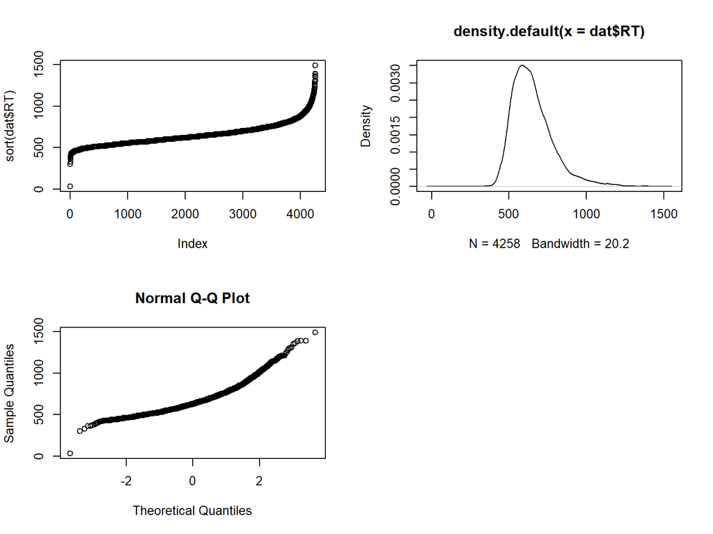

```r
par(mfrow=c(2,2))
plot(sort(dat$RT))
plot(density(dat$RT))
qqnorm(dat$RT)
par(mfrow=c(1,1))
```

# Isključimo nekoliko veoma (besmisleno) brzih odgovora

```r
dat=dat[dat$RT>299,]
dim(dat)
```

```
## [1] 4257   17
```

# Proverimo koja transformacija RT je preporučena

```r
powerTransform(dat$RT)
```

```
## Estimated transformation parameter
##     dat$RT
## -0.9260321
```

# Primenimo inverznu transformaciju

```r
dat$RT=-1000/dat$RT
```

# Pogledamo kako je distribuirano novo RT

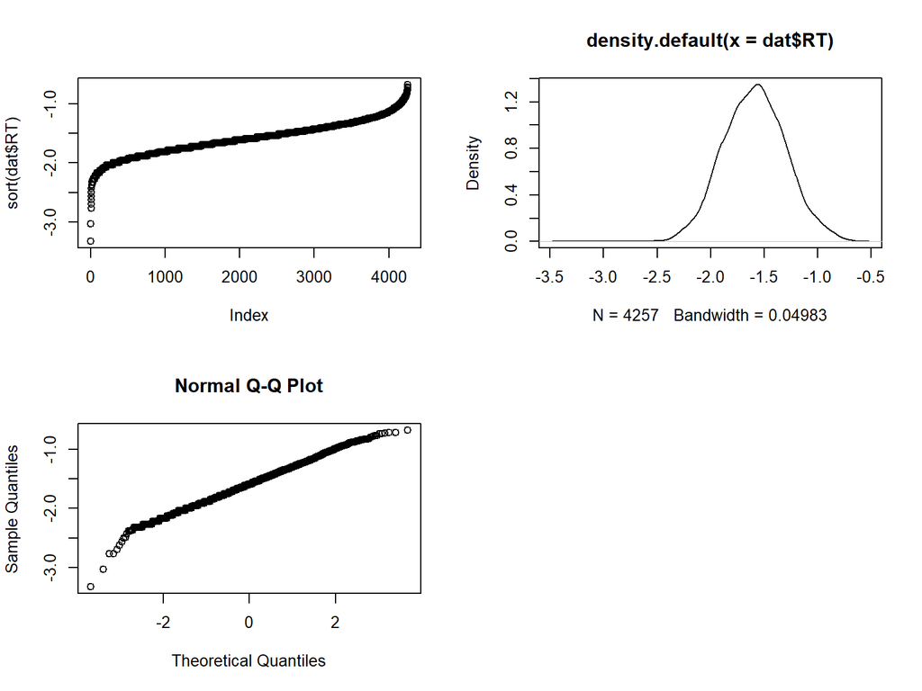

```r
par(mfrow=c(2,2))
plot(sort(dat$RT))
plot(density(dat$RT))
qqnorm(dat$RT)
par(mfrow=c(1,1))
```

# Možemo i da testiramo normalnost

```r
shapiro.test(dat$RT)
```

```
##
##  Shapiro-Wilk normality test
##
## data:  dat$RT
## W = 0.99676, p-value = 5.912e-08
```

```r
ks.test(jitter(dat$RT),"pnorm",mean(dat$RT),sd(dat$RT))
```

```
##
##  One-sample Kolmogorov-Smirnov test
##
## data:  jitter(dat$RT)
## D = 0.022357, p-value = 0.02837
## alternative hypothesis: two-sided
```

# Odmah definišemo i inverznu funkciju, koja će nam biti potrebna za lepu y osu prilikom plotovanja RT

```r
trans <- function(x){
  rezultat <- -1000/x
  return(rezultat)
}
```

# pošto je glavna varijabla u ovoj analizi H

- iskoristićemo nju da ilustrujemo kako se koristi funkcija trans
- istovremeno, ovde već vidimo da ovaj efekat može biti nelinearan

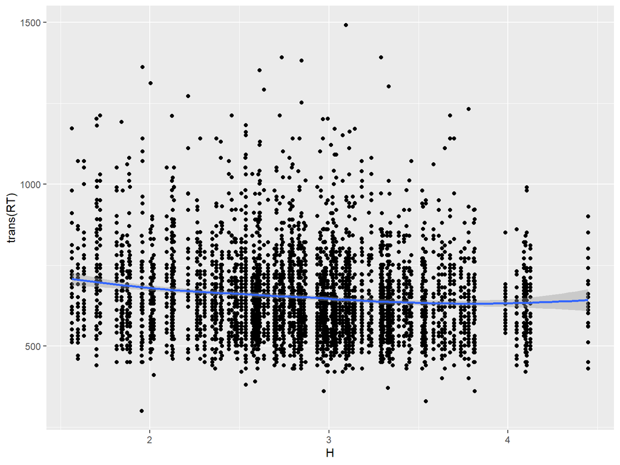

```r
ggplot(dat, aes(x=H, y=trans(RT))) +
  geom_point() +
  geom_smooth(method = "loess", se = TRUE)
```

# Logaritmujemo frekvenciju

```r
dat$freko=log(dat$freko)
```

# Ispitamo kolinearnost među prediktorima

```r
collin.fnc(dat[,c("len", "ort", "freko", "fam","conc", "H" )])$cnumber
```

```
## [1] 63.77733
```

- Kapa koeficijent je ogroman.
- 0-6 nizak
- 15-29 umeren
- > 29 visok

# Pošto je Kappa koeficijent katastrofalno veliki, moraćemo da rešimo problem kolinearnosti. Prvo da pogledamo kako izgleda odnos između varijabli

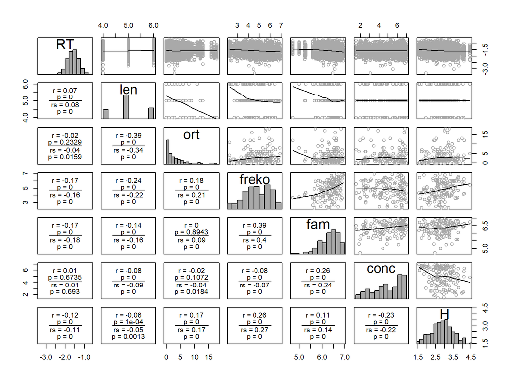

```r
pairscor.fnc(dat[,c("RT", "len", "ort", "freko", "fam","conc", "H")], hist=TRUE, smooth=TRUE, cex.point=1, col.points="darkgrey")
```

# Postoji nekoliko strategija za rešavanje kolinearnosti

- jedna varijanta je da izaberemo prediktore koji su najuticajniji
- ili da iz svake grupe srodnih prediktora izaberemo jedan
- ili da od nekoliko srodnih napravimo novi skor
- ili da izvedemo analizu glavnih komponenti
- za početak, da vidimo kako se rangiraju prediktori po svom uticaju na zavisnu varijablu

# randomForest

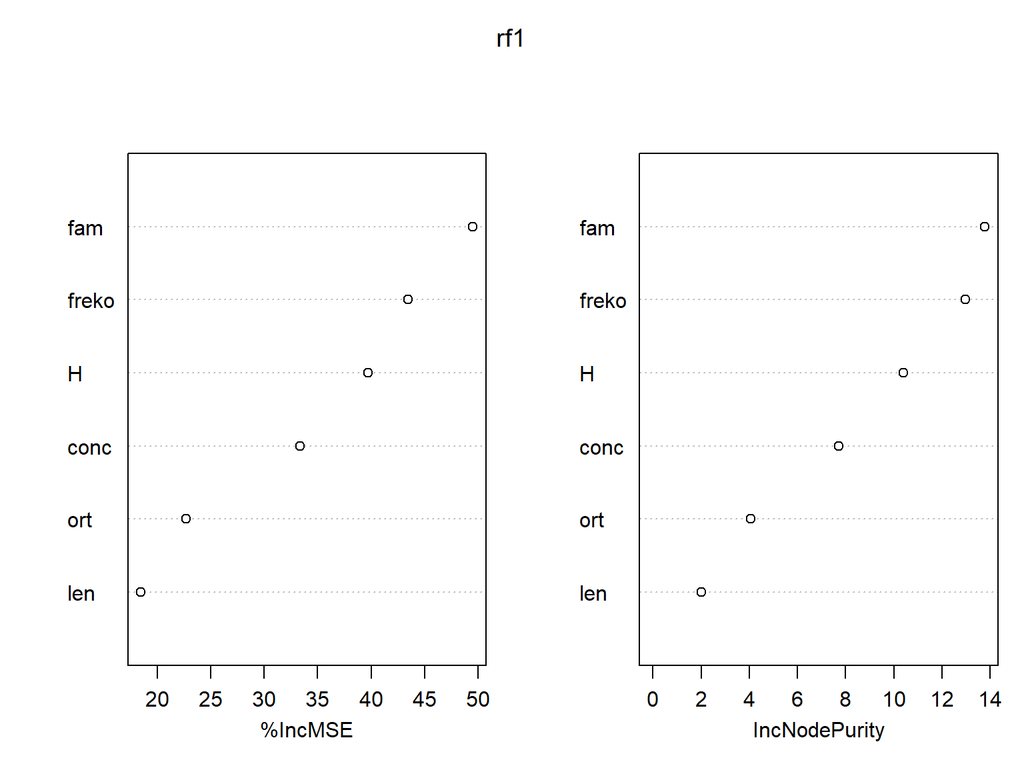

```r
rf1 <- randomForest(RT ~ ., data = dat[,c("RT", "len", "ort", "freko", "fam","conc", "H")], importance = TRUE)

varImpPlot(rf1)
```

```r
importance(rf1)
```

```
##        %IncMSE IncNodePurity
## len   18.48914      2.022418
## ort   22.69456      4.056517
## freko 43.43275     12.985984
## fam   49.49994     13.781342
## conc  33.34325      7.713190
## H     39.73512     10.396102
```

# Gradient Boosting Machines

```r
dat.gbm = dat[,c("RT", "len", "ort", "freko", "fam","conc", "H")]

set.seed(125)
gbm1 = summary(gbm1 <- gbm(RT ~
                             len + ort + freko + fam + conc + H,
                           data=dat.gbm, n.trees=500, interaction.depth=3, shrinkage=0.001, cv.folds=5))
```

```
## Distribution not specified, assuming gaussian ...
```

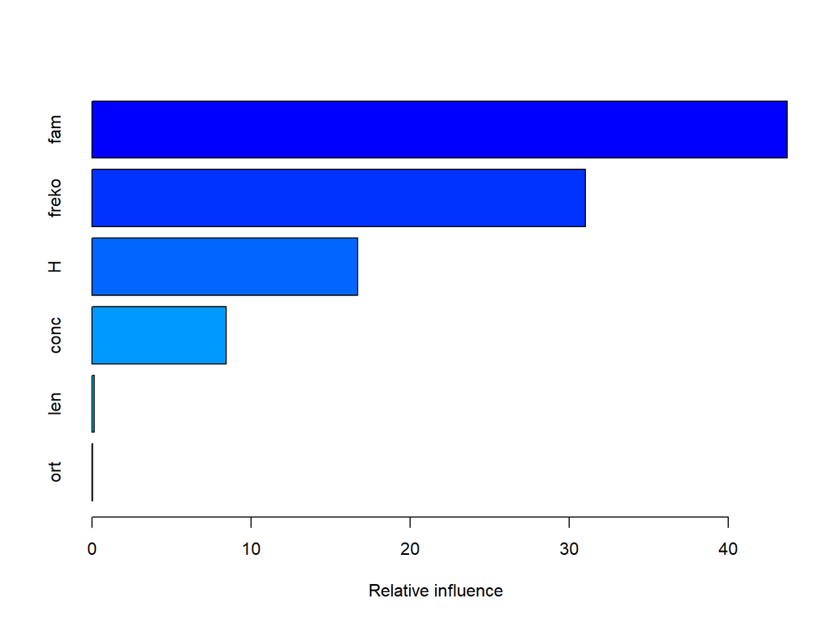

```r
gbm1
```

```
##         var     rel.inf
## fam     fam 43.70614443
## freko freko 31.01100280
## H         H 16.68962277
## conc   conc  8.43056028
## len     len  0.12665757
## ort     ort  0.03601215
```

# pošto u ovoj analizi želimo da pokažemo da H radi preko kontrolnih, poznatih varijabli, tj. ne interesuju nas pojedinačne kontrolne varijable, biramo drugi pristup, izvodimo analizu glavnih komponenti na skupu kontrolnih varijabli

```r
dat.pca = prcomp(dat[,c("len", "ort","freko","fam", "conc")],
                 center = TRUE,
                 scale. = TRUE)

summary(dat.pca)
```

```
## Importance of components:
##                           PC1    PC2    PC3    PC4    PC5
## Standard deviation     1.3033 1.1086 1.0042 0.7678 0.6888
## Proportion of Variance 0.3397 0.2458 0.2017 0.1179 0.0949
## Cumulative Proportion  0.3397 0.5855 0.7872 0.9051 1.0000
```

# da plotujemo varijansu

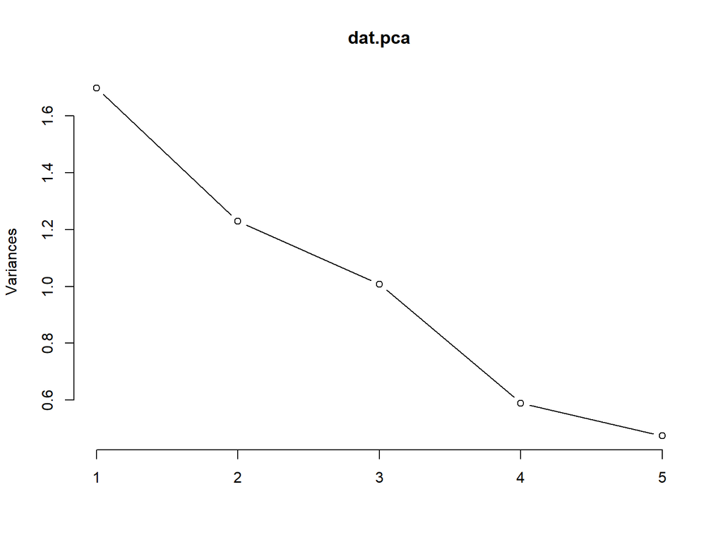

```r
plot(dat.pca, type = "l")
```

# da plotujemo procenat objašnjene varijanse

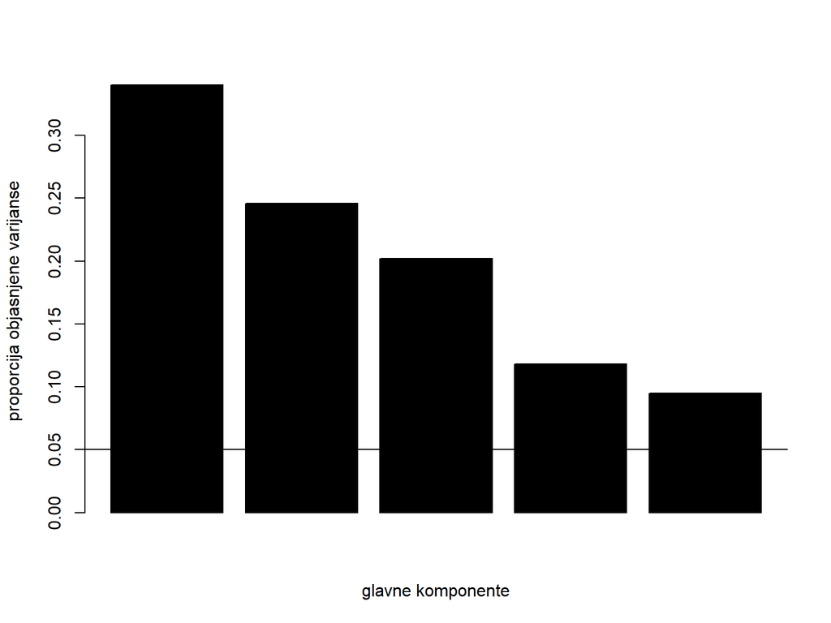

```r
props = round((dat.pca$sdev ^ 2 / sum(dat.pca$sdev ^ 2)), 3)
barplot(props, col = as.numeric (props > 0.05),
        xlab = "glavne komponente",
        ylab = "proporcija objasnjene varijanse")
abline (h = 0.05)
```

- svi objašnjavaju barem 5% varijanse, zadržavamo ih sve

# da vidimo loadings

```r
dat.pca$rotation
```

```
##              PC1         PC2        PC3        PC4         PC5
## len    0.5342907 -0.28585236 -0.3155541 0.72968541  0.02840235
## ort   -0.4324293  0.51552262  0.2964444 0.65374684 -0.17882134
## freko -0.5365440 -0.04662957 -0.5645691 0.10646196  0.61633905
## fam   -0.4641173 -0.56113658 -0.2116484 0.05377134 -0.64964183
## conc  -0.1557370 -0.57920315  0.6700843 0.16108622  0.40658074
```

# pišemo koordinate svih reči u prostoru novih dimenzija, pravimo nove, nekolinearne kontrolne varijable

```r
dat$pc_1 = dat.pca$x[,1]
dat$pc_2 = dat.pca$x[,2]
dat$pc_3 = dat.pca$x[,3]
dat$pc_4 = dat.pca$x[,4]
dat$pc_5 = dat.pca$x[,5]
```

# Ispitamo kolinearnost u novom setu

```r
collin.fnc(dat[,c("pc_1","pc_2","pc_3", "pc_4","pc_5", "H" )])$cnumber
```

```
## [1] 10.35495
```

#- ovo je već prihvatljivije - vidimo da je H slabo-umereno korelirana sa nekim od komponenti - međutim, ostavićemo ovako, Kappa koeficijent je umeren, prihvatljivije - a mi želimo da pokažemo da H radi preko kontrolnih

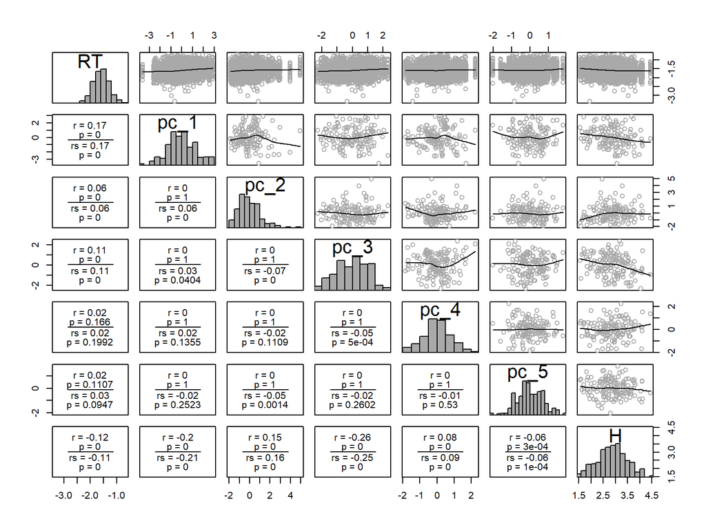

```r
pairscor.fnc(dat[,c("RT", "pc_1","pc_2","pc_3", "pc_4","pc_5", "H")], hist=TRUE, smooth=TRUE, cex.point=1, col.points="darkgrey")
```

# Standardizujemo prediktore

```r
dat$trial.z = scale(dat$Trial_order)
dat$freko.z = scale(dat$freko)
dat$len.z = scale(dat$len)
dat$fam.z = scale(dat$fam)
dat$conc.z = scale(dat$conc)
dat$ort.z = scale(dat$ort)
dat$N.z = scale(dat$N)
dat$T.z = scale(dat$T)
dat$H.z = scale(dat$H)
dat$PC1 = scale(dat$pc_1)
dat$PC2 = scale(dat$pc_2)
dat$PC3 = scale(dat$pc_3)
dat$PC4 = scale(dat$pc_4)
dat$PC5 = scale(dat$pc_5)
```

# pogledamo kolinearnost posle skaliranja

```r
collin.fnc(dat[,c("PC1","PC2","PC3", "PC4","PC5", "H.z" )])$cnumber
```

```
## [1] 1.478941
```

# pored Kappa koeficijenta, može da se koristi i VIF (variance inflation factor)

- VIF veći od 5 ili 10 smatra se velikim

```r
vif(lm(RT ~ len + ort + freko + fam + conc + H, data = dat))
```

```
##      len      ort    freko      fam     conc        H
## 1.239845 1.230137 1.346587 1.335932 1.191328 1.161114
```

# SAD MOŽEO DA PREĐEMO NA FITOVANJE MODELA

- VAŽNA NAPOMENA
- STATISTIČKO MODELOVANJE JE KOMBINACIJA NAUKE I VEŠTINE
- NIKADA NEĆETE DO KRAJA SAVLADATI TEHNIKU
- UVEK SE POJAVLJUJU NOVE PREOPORUKE
- I NOVA “PRAVILA” KOJA TREBA POŠTOVATI
- KAO I NOVI NAČINI DA SE TO UČINI

# STRATEGIJA 1

- krenemo od najjednostavnijeg modela
- dodajemo jedan po jedan parametar
- poredimo modele
- ako nema razlike, parametar nije opravdan
- ako ima razlike, parametar jeste opravdan, zadržavamo ga

# Počinjemo sa osnovnim modelima koji imaju samo intercept među fiksnim efektima

- samo ispitanike, odnosno samo reči kao random,
- poredimo sa modelom koji ima oba, da budemo sigurni u doprinos

```r
lmer0a <- lmer(RT ~ 1 +
                 (1 |Participant),
               data=dat, REML=FALSE)
```

```r
lmer0b <- lmer(RT ~ 1 +
                 (1 |Word),
               data=dat, REML=FALSE)
```

```r
lmer0 <- lmer(RT ~ 1 +
                (1 | Participant) +
                (1 | Word),
              data=dat, REML=FALSE)
```

```r
anova(lmer0a, lmer0)
```

```
## Data: dat
## Models:
## lmer0a: RT ~ 1 + (1 | Participant)
## lmer0: RT ~ 1 + (1 | Participant) + (1 | Word)
##        npar    AIC    BIC  logLik deviance  Chisq Df Pr(>Chisq)
## lmer0a    3 783.86 802.93 -388.93   777.86
## lmer0     4 540.74 566.16 -266.37   532.74 245.13  1  < 2.2e-16 ***
## ---
## Signif. codes:  0 '***' 0.001 '**' 0.01 '*' 0.05 '.' 0.1 ' ' 1
```

```r
anova(lmer0b, lmer0)
```

```
## Data: dat
## Models:
## lmer0b: RT ~ 1 + (1 | Word)
## lmer0: RT ~ 1 + (1 | Participant) + (1 | Word)
##        npar     AIC     BIC  logLik deviance  Chisq Df Pr(>Chisq)
## lmer0b    3 1527.06 1546.13 -760.53  1521.06
## lmer0     4  540.74  566.16 -266.37   532.74 988.33  1  < 2.2e-16 ***
## ---
## Signif. codes:  0 '***' 0.001 '**' 0.01 '*' 0.05 '.' 0.1 ' ' 1
```

# dodajemo redosled izlaganja među prediktore

- prvo vizualizujemo,
- potom pravimo model
- i proveravamo da li je opravdano ukljucivanje tog parametra

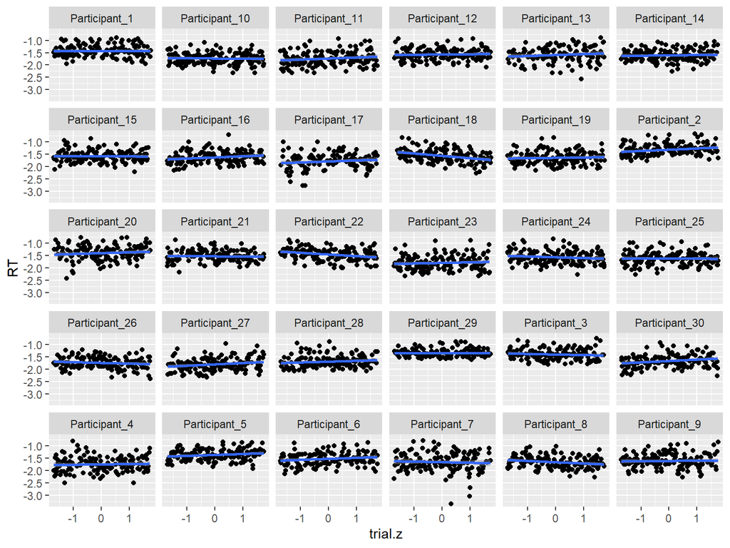

```r
ggplot(dat, aes(x=trial.z, y=RT)) +
  geom_point() +
  geom_smooth(method = "lm", se = TRUE) +
  facet_wrap(~Participant)
```

```r
lmer1a <- lmer(RT ~ trial.z +
                 (1 | Participant) +
                 (1 | Word),
               data=dat, REML=FALSE)
```

```r
anova(lmer0, lmer1a)
```

```
## Data: dat
## Models:
## lmer0: RT ~ 1 + (1 | Participant) + (1 | Word)
## lmer1a: RT ~ trial.z + (1 | Participant) + (1 | Word)
##        npar    AIC    BIC  logLik deviance  Chisq Df Pr(>Chisq)
## lmer0     4 540.74 566.16 -266.37   532.74
## lmer1a    5 534.03 565.81 -262.02   524.03 8.7045  1   0.003174 **
## ---
## Signif. codes:  0 '***' 0.001 '**' 0.01 '*' 0.05 '.' 0.1 ' ' 1
```

# dozvoljavamo redosledu izlaganja da ima razlicit efekat kod razlicitih ispitanika

```r
lmer1b <- lmer(RT ~ trial.z +
                 (1 + trial.z | Participant) +
                 (1 | Word),
               data=dat, REML=FALSE)
```

```r
anova(lmer1b, lmer1a)
```

```
## Data: dat
## Models:
## lmer1a: RT ~ trial.z + (1 | Participant) + (1 | Word)
## lmer1b: RT ~ trial.z + (1 + trial.z | Participant) + (1 | Word)
##        npar    AIC    BIC  logLik deviance  Chisq Df Pr(>Chisq)
## lmer1a    5 534.03 565.81 -262.02   524.03
## lmer1b    7 513.62 558.11 -249.81   499.62 24.412  2  5.002e-06 ***
## ---
## Signif. codes:  0 '***' 0.001 '**' 0.01 '*' 0.05 '.' 0.1 ' ' 1
```

# proveravamo da li je opravdana korelacija između dva parametra u random interakcijama

- tako sto kreiramo model bez korelacije
- pa uporedimo fitove

```r
lmer1bb <- lmer(RT ~ trial.z +
                  (1 + trial.z || Participant) +
                  (1 | Word),
                data=dat, REML=FALSE)
```

```r
anova(lmer1b, lmer1bb)
```

```
## Data: dat
## Models:
## lmer1bb: RT ~ trial.z + (1 + trial.z || Participant) + (1 | Word)
## lmer1b: RT ~ trial.z + (1 + trial.z | Participant) + (1 | Word)
##         npar    AIC    BIC  logLik deviance  Chisq Df Pr(>Chisq)
## lmer1bb    6 512.24 550.38 -250.12   500.24
## lmer1b     7 513.62 558.11 -249.81   499.62 0.6229  1       0.43
```

- nije opravdana korelacija

# slučajna interakcija redosleda sa rečima

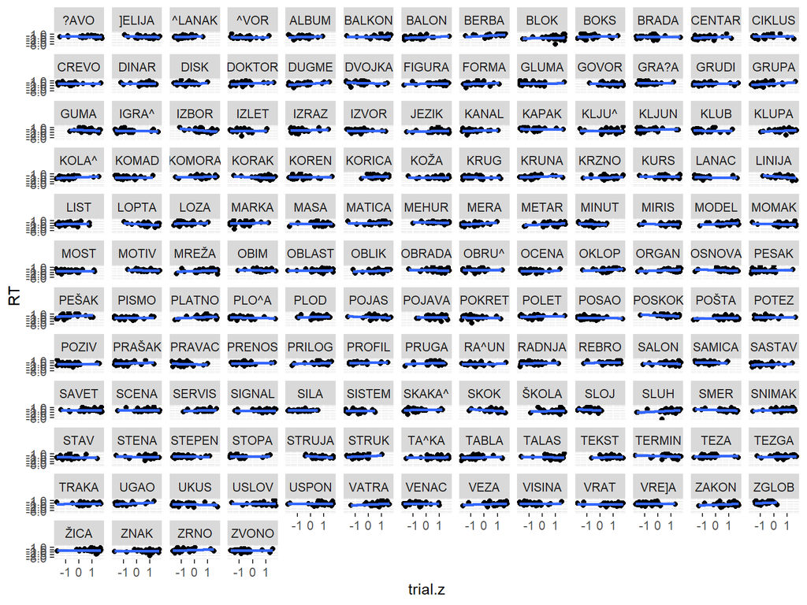

```r
ggplot(dat, aes(x=trial.z, y=RT)) +
  geom_point() +
  geom_smooth(method = "lm", se = TRUE) +
  facet_wrap(~Word)
```

- ako se ne vidi lepo slika, možemo da je sačuvamo pa gledamo otvoreni fajl

```r
ggsave("random.trial.word.jpg", width = 25, height = 25)
lmer1c <- lmer(RT ~ trial.z +
                 (1 + trial.z || Participant) +
                 (1 + trial.z | Word),
               data=dat, REML=FALSE)
```

```
## boundary (singular) fit: see ?isSingular
```

```r
anova(lmer1bb, lmer1c)
```

```
## Data: dat
## Models:
## lmer1bb: RT ~ trial.z + (1 + trial.z || Participant) + (1 | Word)
## lmer1c: RT ~ trial.z + (1 + trial.z || Participant) + (1 + trial.z | Word)
##         npar    AIC    BIC  logLik deviance  Chisq Df Pr(>Chisq)
## lmer1bb    6 512.24 550.38 -250.12   500.24
## lmer1c     8 516.00 566.85 -250.00   500.00 0.2462  2     0.8842
```

- nije opravdana, vraćamo se na prethodni model, lmer1bb

# dodajem prvi sledeći prediktor

- i proveravamo da li je opravdano njegovo uključicanje u model
- tj. da li doprinosi objašnjenoj varijansi

```r
lmer2 <- lmer(RT ~ trial.z + PC1 +
                (1 + trial.z || Participant) +
                (1 | Word),
              data=dat, REML=FALSE)
```

```r
anova(lmer1bb, lmer2)
```

```
## Data: dat
## Models:
## lmer1bb: RT ~ trial.z + (1 + trial.z || Participant) + (1 | Word)
## lmer2: RT ~ trial.z + PC1 + (1 + trial.z || Participant) + (1 | Word)
##         npar    AIC    BIC  logLik deviance  Chisq Df Pr(>Chisq)
## lmer1bb    6 512.24 550.38 -250.12   500.24
## lmer2      7 472.15 516.64 -229.07   458.15 42.094  1  8.697e-11 ***
## ---
## Signif. codes:  0 '***' 0.001 '**' 0.01 '*' 0.05 '.' 0.1 ' ' 1
```

# dodajemo ga u slučajne efekte

```r
lmer2a <- lmer(RT ~ trial.z + PC1 +
                 (1 + PC1 | Participant) + (0 + trial.z | Participant) +
                 (1 | Word),
               data=dat, REML=FALSE)
```

```
## boundary (singular) fit: see ?isSingular
```

```r
anova(lmer2, lmer2a)
```

```
## Data: dat
## Models:
## lmer2: RT ~ trial.z + PC1 + (1 + trial.z || Participant) + (1 | Word)
## lmer2a: RT ~ trial.z + PC1 + (1 + PC1 | Participant) + (0 + trial.z | Participant) + (1 | Word)
##        npar    AIC    BIC  logLik deviance  Chisq Df Pr(>Chisq)
## lmer2     7 472.15 516.64 -229.07   458.15
## lmer2a    9 476.10 533.31 -229.05   458.10 0.0449  2     0.9778
```

# da li je opravdana korelacija u slučajnim

```r
lmer2b <- lmer(RT ~ trial.z + PC1 +
                 (1 | Participant) + (0 + trial.z | Participant) +
                 (0 + PC1 | Participant) +
                 (1 | Word),
               data=dat, REML=FALSE)
```

```
## boundary (singular) fit: see ?isSingular
```

```r
anova(lmer2a, lmer2b)
```

```
## Data: dat
## Models:
## lmer2b: RT ~ trial.z + PC1 + (1 | Participant) + (0 + trial.z | Participant) + (0 + PC1 | Participant) + (1 | Word)
## lmer2a: RT ~ trial.z + PC1 + (1 + PC1 | Participant) + (0 + trial.z | Participant) + (1 | Word)
##        npar    AIC    BIC  logLik deviance  Chisq Df Pr(>Chisq)
## lmer2b    8 474.15 525.00 -229.07   458.15
## lmer2a    9 476.10 533.31 -229.05   458.10 0.0449  1     0.8322
```

- nije opravdana

# testiramo njegovu nelinearnost

```r
lmer2c <- lmer(RT ~ trial.z + poly(PC1,2) +
                 (1 | Participant) + (0 + trial.z | Participant) +
                 (0 + PC1 | Participant) +
                 (1 | Word),
               data=dat, REML=FALSE)
```

```
## boundary (singular) fit: see ?isSingular
```

```r
anova(lmer2b, lmer2c)
```

```
## Data: dat
## Models:
## lmer2b: RT ~ trial.z + PC1 + (1 | Participant) + (0 + trial.z | Participant) + (0 + PC1 | Participant) + (1 | Word)
## lmer2c: RT ~ trial.z + poly(PC1, 2) + (1 | Participant) + (0 + trial.z | Participant) + (0 + PC1 | Participant) + (1 | Word)
##        npar    AIC    BIC  logLik deviance  Chisq Df Pr(>Chisq)
## lmer2b    8 474.15 525.00 -229.07   458.15
## lmer2c    9 474.29 531.49 -228.14   456.29 1.8635  1     0.1722
```

# i tako redom za sve prediktore, gradimo model

- i proveravamo da li je dodatna komplikacija opravdana podacima
- ako uđemo u zonu u kojoj konvergencija više nije moguća
- pojednostavimo strukturu slučajnih efekata
- kako bismo testirali fiksne
- pa kad napravimo konačnu strukturu fiksnih
- ponovimo testiranje sa dodatom složenijom strukturom slučajnih efekata

# sad ćemo, potkrepljenja radi odmah dodati H

```r
lmer3a <- lmer(RT ~ trial.z + PC1 + H.z +
                 (1 | Participant) + (0 + trial.z | Participant) +
                 (0 + PC1 | Participant) +
                 (1 | Word),
               data=dat, REML=FALSE)
```

```
## boundary (singular) fit: see ?isSingular
```

```r
anova(lmer2b, lmer3a)
```

```
## Data: dat
## Models:
## lmer2b: RT ~ trial.z + PC1 + (1 | Participant) + (0 + trial.z | Participant) + (0 + PC1 | Participant) + (1 | Word)
## lmer3a: RT ~ trial.z + PC1 + H.z + (1 | Participant) + (0 + trial.z | Participant) + (0 + PC1 | Participant) + (1 | Word)
##        npar    AIC    BIC  logLik deviance  Chisq Df Pr(>Chisq)
## lmer2b    8 474.15 525.00 -229.07   458.15
## lmer3a    9 460.12 517.32 -221.06   442.12 16.034  1  6.221e-05 ***
## ---
## Signif. codes:  0 '***' 0.001 '**' 0.01 '*' 0.05 '.' 0.1 ' ' 1
```

# dodajemo ga u slučajne efekte

```r
lmer3b <- lmer(RT ~ trial.z + PC1 + H.z +
                 (1 + H.z| Participant) + (0 + trial.z | Participant) +
                 (0 + PC1 | Participant) +
                 (1 | Word),
               data=dat, REML=FALSE)
```

```
## boundary (singular) fit: see ?isSingular
```

```r
anova(lmer3a, lmer3b)
```

```
## Data: dat
## Models:
## lmer3a: RT ~ trial.z + PC1 + H.z + (1 | Participant) + (0 + trial.z | Participant) + (0 + PC1 | Participant) + (1 | Word)
## lmer3b: RT ~ trial.z + PC1 + H.z + (1 + H.z | Participant) + (0 + trial.z | Participant) + (0 + PC1 | Participant) + (1 | Word)
##        npar    AIC    BIC  logLik deviance  Chisq Df Pr(>Chisq)
## lmer3a    9 460.12 517.32 -221.06   442.12
## lmer3b   11 461.58 531.50 -219.79   439.58 2.5353  2     0.2815
```

# da li je opravdana korelacija

```r
lmer3c <- lmer(RT ~ trial.z + PC1 + H.z +
                 (1 | Participant) + (0 + trial.z | Participant) +
                 (0 + PC1 | Participant) + (0 + H.z | Participant) +
                 (1 | Word),
               data=dat, REML=FALSE)
```

```
## boundary (singular) fit: see ?isSingular
```

```r
anova(lmer3b, lmer3c)
```

```
## Data: dat
## Models:
## lmer3c: RT ~ trial.z + PC1 + H.z + (1 | Participant) + (0 + trial.z | Participant) + (0 + PC1 | Participant) + (0 + H.z | Participant) + (1 | Word)
## lmer3b: RT ~ trial.z + PC1 + H.z + (1 + H.z | Participant) + (0 + trial.z | Participant) + (0 + PC1 | Participant) + (1 | Word)
##        npar    AIC    BIC  logLik deviance  Chisq Df Pr(>Chisq)
## lmer3c   10 462.12 525.68 -221.06   442.12
## lmer3b   11 461.58 531.50 -219.79   439.58 2.5353  1     0.1113
```

- ne, ali ga ostavljamo za sada, jer je to naš ključni prediktor

# testiramo njegovu nelinearnost

```r
lmer3d <- lmer(RT ~ trial.z + PC1 + poly(H, 2) +
                 (1 + H.z| Participant) + (0 + trial.z | Participant) +
                 (0 + PC1 | Participant) +
                 (1 | Word),
               data=dat, REML=FALSE)
```

```
## boundary (singular) fit: see ?isSingular
```

```r
anova(lmer3c, lmer3d)
```

```
## Data: dat
## Models:
## lmer3c: RT ~ trial.z + PC1 + H.z + (1 | Participant) + (0 + trial.z | Participant) + (0 + PC1 | Participant) + (0 + H.z | Participant) + (1 | Word)
## lmer3d: RT ~ trial.z + PC1 + poly(H, 2) + (1 + H.z | Participant) + (0 + trial.z | Participant) + (0 + PC1 | Participant) + (1 | Word)
##        npar    AIC    BIC  logLik deviance  Chisq Df Pr(>Chisq)
## lmer3c   10 462.12 525.68 -221.06   442.12
## lmer3d   12 460.56 536.84 -218.28   436.56 5.5534  2    0.06224 .
## ---
## Signif. codes:  0 '***' 0.001 '**' 0.01 '*' 0.05 '.' 0.1 ' ' 1
```

- nije nelinearan

# MODEL JE VEĆ PRIJAVIO DA IMA PROBLEMA SA KONFERGENCIJOM

- TO ZNAČI DA SMO VEĆ PREOPTERETILI SLUČAJNIM EFEKTIMA…
- A TEK SMO POČELI

# testiramo interakciju sa fiksnim prediktorima

```r
lmer3e <- lmer(RT ~ trial.z * H.z + PC1 +
                 (1 + H.z| Participant) + (0 + trial.z | Participant) +
                 (0 + PC1 | Participant) +
                 (1 | Word),
               data=dat, REML=FALSE)
```

```
## boundary (singular) fit: see ?isSingular
```

```r
anova(lmer3c, lmer3e)
```

```
## Data: dat
## Models:
## lmer3c: RT ~ trial.z + PC1 + H.z + (1 | Participant) + (0 + trial.z | Participant) + (0 + PC1 | Participant) + (0 + H.z | Participant) + (1 | Word)
## lmer3e: RT ~ trial.z * H.z + PC1 + (1 + H.z | Participant) + (0 + trial.z | Participant) + (0 + PC1 | Participant) + (1 | Word)
##        npar    AIC    BIC  logLik deviance  Chisq Df Pr(>Chisq)
## lmer3c   10 462.12 525.68 -221.06   442.12
## lmer3e   12 461.94 538.21 -218.97   437.94 4.1768  2     0.1239
```

- ova interakcija nije opravdana

```r
lmer3f <- lmer(RT ~ trial.z + PC1 * H.z +
                 (1 + H.z| Participant) + (0 + trial.z | Participant) +
                 (0 + PC1 | Participant) +
                 (1 | Word),
               data=dat, REML=FALSE)
```

```
## boundary (singular) fit: see ?isSingular
```

```r
anova(lmer3c, lmer3f)
```

```
## Data: dat
## Models:
## lmer3c: RT ~ trial.z + PC1 + H.z + (1 | Participant) + (0 + trial.z | Participant) + (0 + PC1 | Participant) + (0 + H.z | Participant) + (1 | Word)
## lmer3f: RT ~ trial.z + PC1 * H.z + (1 + H.z | Participant) + (0 + trial.z | Participant) + (0 + PC1 | Participant) + (1 | Word)
##        npar    AIC    BIC  logLik deviance  Chisq Df Pr(>Chisq)
## lmer3c   10 462.12 525.68 -221.06   442.12
## lmer3f   12 455.78 532.06 -215.89   431.78 10.333  2   0.005705 **
## ---
## Signif. codes:  0 '***' 0.001 '**' 0.01 '*' 0.05 '.' 0.1 ' ' 1
```

- ova interakcija jeste opravdana, za sada je najbolji model lmer3f

# tek kad smo pokazali da neki prediktor doprinosi objašnjenoj varijansi smemo da pogledamo da li je koeficijent stastistički značajan

```r
summary(lmer3f)
```

```
## Linear mixed model fit by maximum likelihood . t-tests use Satterthwaite's
##   method [lmerModLmerTest]
## Formula: RT ~ trial.z + PC1 * H.z + (1 + H.z | Participant) + (0 + trial.z |
##     Participant) + (0 + PC1 | Participant) + (1 | Word)
##    Data: dat
##
##      AIC      BIC   logLik deviance df.resid
##    455.8    532.1   -215.9    431.8     4245
##
## Scaled residuals:
##     Min      1Q  Median      3Q     Max
## -6.5350 -0.6396 -0.0396  0.6216  3.9284
##
## Random effects:
##  Groups        Name        Variance  Std.Dev. Corr
##  Word          (Intercept) 3.897e-03 0.062427
##  Participant   PC1         0.000e+00 0.000000
##  Participant.1 trial.z     8.309e-04 0.028826
##  Participant.2 (Intercept) 1.816e-02 0.134762
##                H.z         3.717e-05 0.006097 1.00
##  Residual                  6.040e-02 0.245773
## Number of obs: 4257, groups:  Word, 147; Participant, 30
##
## Fixed effects:
##               Estimate Std. Error         df t value Pr(>|t|)
## (Intercept)  -1.594415   0.025458  32.794555 -62.629  < 2e-16 ***
## trial.z       0.012192   0.007071  39.819212   1.724  0.09244 .
## PC1           0.045512   0.006587 141.909251   6.909 1.52e-10 ***
## H.z          -0.026690   0.006609 138.282036  -4.039 8.87e-05 ***
## PC1:H.z      -0.019855   0.007007 142.045792  -2.834  0.00527 **
## ---
## Signif. codes:  0 '***' 0.001 '**' 0.01 '*' 0.05 '.' 0.1 ' ' 1
##
## Correlation of Fixed Effects:
##         (Intr) tril.z PC1    H.z
## trial.z  0.001
## PC1     -0.009  0.000
## H.z      0.161 -0.023  0.202
## PC1:H.z  0.056  0.020 -0.141 -0.046
## optimizer (nloptwrap) convergence code: 0 (OK)
## boundary (singular) fit: see ?isSingular
```

# STRATEGIJA 2

- krenemo od najkomplikovanijeg smislenog modela
- izbacujemo jedan po jedan parametar
- poredimo modele
- ako nema razlike, taj parametar nije opravdan
- ako ima razlike, taj parametar je opravdan, zadržavamo ga

```r
lmerXa <- lmer(RT ~ trial.z * PC1 * H.z +
                 (1 + trial.z * PC1 * H.z|Participant) +
                 (1 + trial.z |Word),
               data=dat, REML=FALSE)
```

```
## boundary (singular) fit: see ?isSingular
```

- prvo da pokušamo da pojednostavimo strukturu slučajnih efekata

```r
summary(rePCA(lmerXa))
```

```
## $Word
## Importance of components:
##                          [,1]      [,2]
## Standard deviation     0.2599 0.0002614
## Proportion of Variance 1.0000 0.0000000
## Cumulative Proportion  1.0000 1.0000000
##
## $Participant
## Importance of components:
##                          [,1]    [,2]    [,3]    [,4]      [,5]      [,6]
## Standard deviation     0.5569 0.12432 0.06964 0.04017 0.0001402 6.678e-05
## Proportion of Variance 0.9340 0.04655 0.01461 0.00486 0.0000000 0.000e+00
## Cumulative Proportion  0.9340 0.98053 0.99514 1.00000 1.0000000 1.000e+00
##                             [,7] [,8]
## Standard deviation     1.061e-05    0
## Proportion of Variance 0.000e+00    0
## Cumulative Proportion  1.000e+00    1
```

- ovo često neće da konvergira

# zbog toga je zgodno vratiti se na jednostavniju strukturu slučajnih da olakšamo stvar

```r
lmerX <- lmer(RT ~ trial.z * PC1 * H.z +
                 (1 |Participant) +
                 (1 |Word),
               data=dat, REML=FALSE)
```

# izbacimo jedan parametar, trostruku interakciju, pa napravimo novi model

```r
lmerX1 <- lmer(RT ~ trial.z * PC1 +
                    trial.z * H.z +
                    PC1 * H.z +
                    (1 |Participant) +
                    (1 |Word),
                    data=dat, REML=FALSE)
```

```r
anova(lmerX1, lmerX)
```

```
## Data: dat
## Models:
## lmerX1: RT ~ trial.z * PC1 + trial.z * H.z + PC1 * H.z + (1 | Participant) + (1 | Word)
## lmerX: RT ~ trial.z * PC1 * H.z + (1 | Participant) + (1 | Word)
##        npar    AIC    BIC  logLik deviance  Chisq Df Pr(>Chisq)
## lmerX1   10 477.58 541.14 -228.79   457.58
## lmerX    11 479.56 549.48 -228.78   457.56 0.0166  1     0.8974
```

- nije opravdana trostruka interakcija

# sad iizbacujem po jednu dvostruku

```r
lmerX2 <- lmer(RT ~ trial.z * PC1 +
                 trial.z * H.z +
                 (1 |Participant) +
                 (1 |Word),
               data=dat, REML=FALSE)
```

```r
anova(lmerX1, lmerX2)
```

```
## Data: dat
## Models:
## lmerX2: RT ~ trial.z * PC1 + trial.z * H.z + (1 | Participant) + (1 | Word)
## lmerX1: RT ~ trial.z * PC1 + trial.z * H.z + PC1 * H.z + (1 | Participant) + (1 | Word)
##        npar    AIC    BIC  logLik deviance Chisq Df Pr(>Chisq)
## lmerX2    9 482.88 540.08 -232.44   464.88
## lmerX1   10 477.58 541.14 -228.79   457.58 7.297  1   0.006907 **
## ---
## Signif. codes:  0 '***' 0.001 '**' 0.01 '*' 0.05 '.' 0.1 ' ' 1
```

- interakcija PC1 i H.z je opravdana

```r
lmerX3 <- lmer(RT ~ trial.z * PC1 +
                 PC1 * H.z +
                 (1 |Participant) +
                 (1 |Word),
               data=dat, REML=FALSE)
```

```r
anova(lmerX1, lmerX3)
```

```
## Data: dat
## Models:
## lmerX3: RT ~ trial.z * PC1 + PC1 * H.z + (1 | Participant) + (1 | Word)
## lmerX1: RT ~ trial.z * PC1 + trial.z * H.z + PC1 * H.z + (1 | Participant) + (1 | Word)
##        npar    AIC    BIC  logLik deviance  Chisq Df Pr(>Chisq)
## lmerX3    9 476.40 533.60 -229.20   458.40
## lmerX1   10 477.58 541.14 -228.79   457.58 0.8163  1     0.3663
```

- interakcija trial.z i H.z nije opravdana

```r
lmerX4 <- lmer(RT ~
                 trial.z * H.z +
                 PC1 * H.z +
                 (1 |Participant) +
                 (1 |Word),
               data=dat, REML=FALSE)
```

```r
anova(lmerX1, lmerX4)
```

```
## Data: dat
## Models:
## lmerX4: RT ~ trial.z * H.z + PC1 * H.z + (1 | Participant) + (1 | Word)
## lmerX1: RT ~ trial.z * PC1 + trial.z * H.z + PC1 * H.z + (1 | Participant) + (1 | Word)
##        npar    AIC    BIC  logLik deviance  Chisq Df Pr(>Chisq)
## lmerX4    9 475.68 532.89 -228.84   457.68
## lmerX1   10 477.58 541.14 -228.79   457.58 0.1011  1     0.7505
```

- interakcija trial.z i PC1 nije opravdana

# na osnovu ovih poređenja ostavljamo u modelu samo one parametre čije izbacivanje pravi razliku

- ostavljam samo interakciju koja je opravdana

```r
lmerX5 <- lmer(RT ~ trial.z +
                 PC1 * H.z +
                 (1 |Participant) +
                 (1 |Word),
               data=dat, REML=FALSE)
```

```r
anova(lmerX1, lmerX5)
```

```
## Data: dat
## Models:
## lmerX5: RT ~ trial.z + PC1 * H.z + (1 | Participant) + (1 | Word)
## lmerX1: RT ~ trial.z * PC1 + trial.z * H.z + PC1 * H.z + (1 | Participant) + (1 | Word)
##        npar    AIC    BIC  logLik deviance  Chisq Df Pr(>Chisq)
## lmerX5    8 474.65 525.50 -229.32   458.65
## lmerX1   10 477.58 541.14 -228.79   457.58 1.0708  2     0.5854
```

- nema razlike, dakle jednostavniji model lmerX5 je podjednako uspešan kao komplikovani lmerX1

# proverimo da li su preostali bez interakcije potrebni

- šta je sa glavnim efektom trial.z

```r
lmerX6 <- lmer(RT ~
                 PC1 * H.z +
                 (1 |Participant) +
                 (1 |Word),
               data=dat, REML=FALSE)
```

```r
anova(lmerX5, lmerX6)
```

```
## Data: dat
## Models:
## lmerX6: RT ~ PC1 * H.z + (1 | Participant) + (1 | Word)
## lmerX5: RT ~ trial.z + PC1 * H.z + (1 | Participant) + (1 | Word)
##        npar    AIC    BIC  logLik deviance  Chisq Df Pr(>Chisq)
## lmerX6    7 480.78 525.27 -233.39   466.78
## lmerX5    8 474.65 525.50 -229.32   458.65 8.1299  1   0.004354 **
## ---
## Signif. codes:  0 '***' 0.001 '**' 0.01 '*' 0.05 '.' 0.1 ' ' 1
```

- opravdan je
- i dalje je najbolji model lmerX5

# sada vraćam slučajne interakcije

- AKO MODEL NEĆE DA KONVERGIRA, PRVO IZBACIVATI KORELACIJE IZMEĐU SLUČAJNIH EFEKATA

```r
lmerY <- lmer(RT ~ trial.z +
                 PC1 * H.z +
                 (1 + trial.z + PC1 * H.z | Participant) +
                 (1 + trial.z | Word),
               data=dat, REML=FALSE)
```

```
## boundary (singular) fit: see ?isSingular
```

```r
anova(lmerX6, lmerY)
```

```
## Data: dat
## Models:
## lmerX6: RT ~ PC1 * H.z + (1 | Participant) + (1 | Word)
## lmerY: RT ~ trial.z + PC1 * H.z + (1 + trial.z + PC1 * H.z | Participant) + (1 + trial.z | Word)
##        npar    AIC    BIC  logLik deviance  Chisq Df Pr(>Chisq)
## lmerX6    7 480.78 525.27 -233.39   466.78
## lmerY    24 472.94 625.49 -212.47   424.94 41.837 17   0.000708 ***
## ---
## Signif. codes:  0 '***' 0.001 '**' 0.01 '*' 0.05 '.' 0.1 ' ' 1
```

- sve ove slučajne interakcije doprinose zajedno
- ali # da proverimo da li su svi slučajni efekti opravdani

```r
summary(rePCA(lmerY))
```

```
## $Word
## Importance of components:
##                          [,1]      [,2]
## Standard deviation     0.2547 4.855e-05
## Proportion of Variance 1.0000 0.000e+00
## Cumulative Proportion  1.0000 1.000e+00
##
## $Participant
## Importance of components:
##                          [,1]    [,2]    [,3]      [,4] [,5]
## Standard deviation     0.5542 0.12173 0.04132 6.485e-06    0
## Proportion of Variance 0.9489 0.04579 0.00527 0.000e+00    0
## Cumulative Proportion  0.9489 0.99473 1.00000 1.000e+00    1
```

- VIDIMO DA JE U SLUČAJU REČI KOMPLETNA VARIJANSA OBJAŠNJENA VEĆ SA JEDNOM GLAVNOM KOMPONENTOM, A U SLUČAJU ISPITANIKA VEĆ SA 3 GLAVNE KOMPONENTE
- TO ZNAČI DA JE OPRAVDANO IZBACITI 2 PARAMETARA IZ STRUKTURE SLUČAJNIH EFEKATA PO ISPITANICIMA
- TAKOĐE, OPRAVDANO JE ISKLJUČITI JEDAN PARAMETAR IZ STRUKTURE SLUČAJNIH EFEKATA PO REČIMA
- po WORD
- dovoljan jedan, zadržavamo onaj sa većom varijasnom
- po PARTICIPANT
- dovoljna 3
- izbacujemo dva sa najmanjom varijansom

# PRIKAŽEMO KOEFICIJENTE DA BISMO DETEKTOVALI KOMPONENTE SA NAJMANJOM VARIJANSOM KOJE ĆEMO IZBACITI

```r
lmerY
```

```
## Linear mixed model fit by maximum likelihood  ['lmerModLmerTest']
## Formula: RT ~ trial.z + PC1 * H.z + (1 + trial.z + PC1 * H.z | Participant) +
##     (1 + trial.z | Word)
##    Data: dat
##       AIC       BIC    logLik  deviance  df.resid
##  472.9428  625.4945 -212.4714  424.9428      4233
## Random effects:
##  Groups      Name        Std.Dev. Corr
##  Word        (Intercept) 0.062482
##              trial.z     0.001096 -1.00
##  Participant (Intercept) 0.135619
##              trial.z     0.028617 -0.19
##              PC1         0.006151  0.31 -0.19
##              H.z         0.010234  0.64 -0.42  0.90
##              PC1:H.z     0.011264  0.34 -0.88  0.63  0.78
##  Residual                0.245344
## Number of obs: 4257, groups:  Word, 147; Participant, 30
## Fixed Effects:
## (Intercept)      trial.z          PC1          H.z      PC1:H.z
##    -1.59453      0.01187      0.04539     -0.02673     -0.02003
## optimizer (nloptwrap) convergence code: 0 (OK) ; 0 optimizer warnings; 1 lme4 warnings
```

# Uporedimo dva modela

```r
lmerY1 <- lmer(RT ~ trial.z +
                PC1 * H.z +
                (1 + trial.z + H.z | Participant) +
                (1 | Word),
              data=dat, REML=FALSE)
```

```
## boundary (singular) fit: see ?isSingular
```

```r
anova(lmerY, lmerY1)
```

```
## Data: dat
## Models:
## lmerY1: RT ~ trial.z + PC1 * H.z + (1 + trial.z + H.z | Participant) + (1 | Word)
## lmerY: RT ~ trial.z + PC1 * H.z + (1 + trial.z + PC1 * H.z | Participant) + (1 + trial.z | Word)
##        npar    AIC    BIC  logLik deviance  Chisq Df Pr(>Chisq)
## lmerY1   13 456.79 539.43 -215.40   430.79
## lmerY    24 472.94 625.49 -212.47   424.94 5.8503 11     0.8832
```

- nema razlike između dva modela
- dakle, komplikacije su bile nepotrebne
- konačni model je lmerY1

# tek sad smemo da pogledamo koeficijente

```r
summary(lmerY1)
```

```
## Linear mixed model fit by maximum likelihood . t-tests use Satterthwaite's
##   method [lmerModLmerTest]
## Formula: RT ~ trial.z + PC1 * H.z + (1 + trial.z + H.z | Participant) +
##     (1 | Word)
##    Data: dat
##
##      AIC      BIC   logLik deviance df.resid
##    456.8    539.4   -215.4    430.8     4244
##
## Scaled residuals:
##     Min      1Q  Median      3Q     Max
## -6.5308 -0.6393 -0.0382  0.6169  3.9430
##
## Random effects:
##  Groups      Name        Variance  Std.Dev. Corr
##  Word        (Intercept) 3.907e-03 0.062507
##  Participant (Intercept) 1.816e-02 0.134768
##              trial.z     8.389e-04 0.028964 -0.18
##              H.z         4.565e-05 0.006756  0.92 -0.56
##  Residual                6.039e-02 0.245749
## Number of obs: 4257, groups:  Word, 147; Participant, 30
##
## Fixed effects:
##               Estimate Std. Error         df t value Pr(>|t|)
## (Intercept)  -1.594399   0.025460  32.802618 -62.623  < 2e-16 ***
## trial.z       0.012304   0.007091  39.727679   1.735  0.09045 .
## PC1           0.045487   0.006592 141.866519   6.900 1.59e-10 ***
## H.z          -0.026706   0.006635 135.863644  -4.025 9.43e-05 ***
## PC1:H.z      -0.019841   0.007012 142.003860  -2.829  0.00534 **
## ---
## Signif. codes:  0 '***' 0.001 '**' 0.01 '*' 0.05 '.' 0.1 ' ' 1
##
## Correlation of Fixed Effects:
##         (Intr) tril.z PC1    H.z
## trial.z -0.128
## PC1     -0.009  0.000
## H.z      0.163 -0.100  0.201
## PC1:H.z  0.056  0.020 -0.141 -0.046
## optimizer (nloptwrap) convergence code: 0 (OK)
## boundary (singular) fit: see ?isSingular
```

# treba još proveriti da li su efekti nelinearni

# na kraju prelazimo na dijagnostiku

```r
confint(lmerY1, method="Wald")
```

```
##                    2.5 %       97.5 %
## .sig01                NA           NA
## .sig02                NA           NA
## .sig03                NA           NA
## .sig04                NA           NA
## .sig05                NA           NA
## .sig06                NA           NA
## .sig07                NA           NA
## .sigma                NA           NA
## (Intercept) -1.644300154 -1.544496957
## trial.z     -0.001593653  0.026202164
## PC1          0.032566592  0.058408256
## H.z         -0.039710747 -0.013700469
## PC1:H.z     -0.033585460 -0.006097356
```

- Vidimo da se naši efekti uvek nalaze sa iste strane nule
- osim efekta redosleda, koji nije baš pouzdan

# Sada ćemo da proverimo da li su prekršeni neki od preduslova za primenu linernog modela:

- Napravimo kolonu sa predviđenim vrednostima ZV:

```r
dat$RT.fitted = predict(lmerY1)
```

- Napravimo kolonu sa rezidualima:

```r
dat$RT.res = residuals(lmerY1)
```

- Plotujemo korelaciju između fitovanih vrednosti i reziduala
- Da proverimo da li postoji homogenost varijanse
- Ovo treba da bude jedno lepo “jaje”

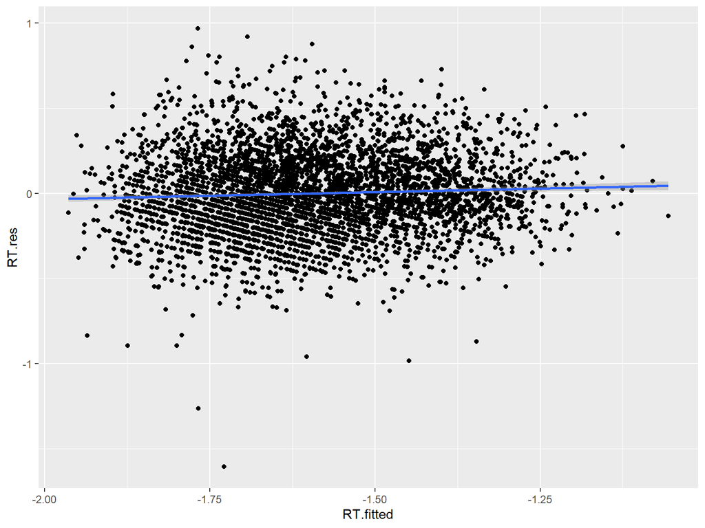

```r
ggplot(dat, aes(x=RT.fitted, y=RT.res)) +
  geom_point() +
  geom_smooth(method = "lm", se = TRUE)
```

# Da proverimo da li se reziduali normalno distribuiraju

- Ovo treba da bude što sličnije ravnoj liniji:

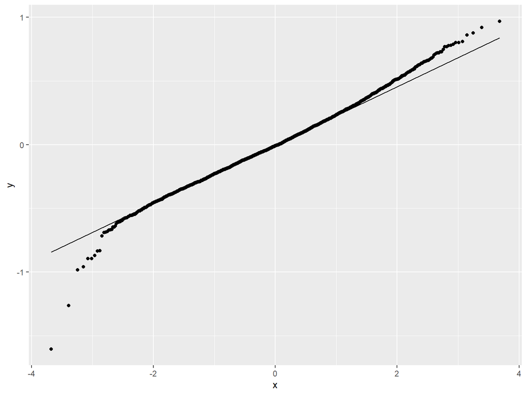

```r
ggplot(dat, aes(sample=RT.res)) +
  stat_qq() + stat_qq_line()
```

# Isto to može i ovako:

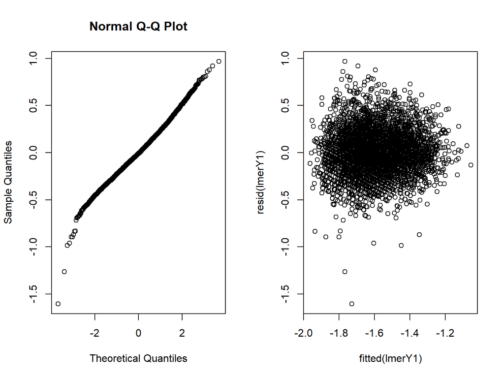

```r
par(mfcol=c(1,2))
qqnorm(resid(lmerY1))
plot(fitted(lmerY1), resid(lmerY1))
```

```r
par(mfcol=c(1,1))
```

# Sad ćemo da izbacimo tačke sa velikim rezidualima

- I da proverimo da li utiču previše na model
- Refitujemo model na podskupu tačaka čiji su reziduali unutar opsega +/-2.5 sigme

```r
lmerY1t <- lmer(RT ~ trial.z +
                 PC1 * H.z +
                 (1 + trial.z + H.z | Participant) +
                 (1 | Word),
                 data=dat,
                 subset=abs(scale(resid(lmerY1)))<2.5,
                 REML=FALSE)
```

```
## boundary (singular) fit: see ?isSingular
```

- Uporedimo koeficijente iz pročišćenog i originalnog modela
- ne bi trebalo da se dese drastične promene

```r
summary(lmerY1t)
```

```
## Linear mixed model fit by maximum likelihood . t-tests use Satterthwaite's
##   method [lmerModLmerTest]
## Formula: RT ~ trial.z + PC1 * H.z + (1 + trial.z + H.z | Participant) +
##     (1 | Word)
##    Data: dat
##  Subset: abs(scale(resid(lmerY1))) < 2.5
##
##      AIC      BIC   logLik deviance df.resid
##   -215.7   -133.3    120.9   -241.7     4173
##
## Scaled residuals:
##      Min       1Q   Median       3Q      Max
## -2.64785 -0.67143 -0.04184  0.67368  2.68289
##
## Random effects:
##  Groups      Name        Variance  Std.Dev. Corr
##  Word        (Intercept) 3.775e-03 0.061443
##  Participant (Intercept) 1.881e-02 0.137151
##              trial.z     8.425e-04 0.029025 -0.22
##              H.z         3.023e-05 0.005498  0.90 -0.62
##  Residual                5.122e-02 0.226326
## Number of obs: 4186, groups:  Word, 147; Participant, 30
##
## Fixed effects:
##               Estimate Std. Error         df t value Pr(>|t|)
## (Intercept)  -1.597905   0.025824  32.625525 -61.877  < 2e-16 ***
## trial.z       0.011045   0.006922  39.525474   1.596  0.11855
## PC1           0.047998   0.006358 142.177325   7.550 4.81e-12 ***
## H.z          -0.025538   0.006363 139.000031  -4.013 9.74e-05 ***
## PC1:H.z      -0.021056   0.006759 141.955408  -3.115  0.00222 **
## ---
## Signif. codes:  0 '***' 0.001 '**' 0.01 '*' 0.05 '.' 0.1 ' ' 1
##
## Correlation of Fixed Effects:
##         (Intr) tril.z PC1    H.z
## trial.z -0.161
## PC1     -0.009  0.000
## H.z      0.137 -0.096  0.203
## PC1:H.z  0.053  0.019 -0.141 -0.046
## optimizer (nloptwrap) convergence code: 0 (OK)
## boundary (singular) fit: see ?isSingular
```

# ponovimo dijagnostiku

- sad bi trebalo da je situacija još bolja

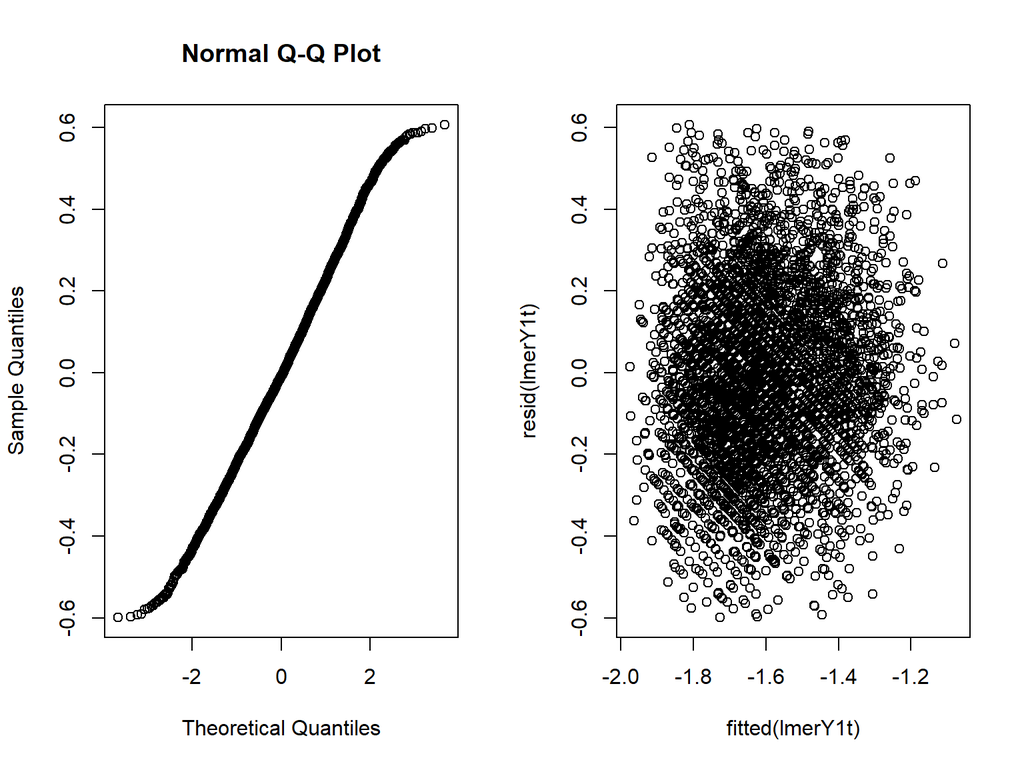

```r
par(mfcol=c(1,2))
qqnorm(resid(lmerY1t))
plot(fitted(lmerY1t), resid(lmerY1t))
```

```r
par(mfcol=c(1,1))
```

# viizualizujemo finalno efekat glavne varijable

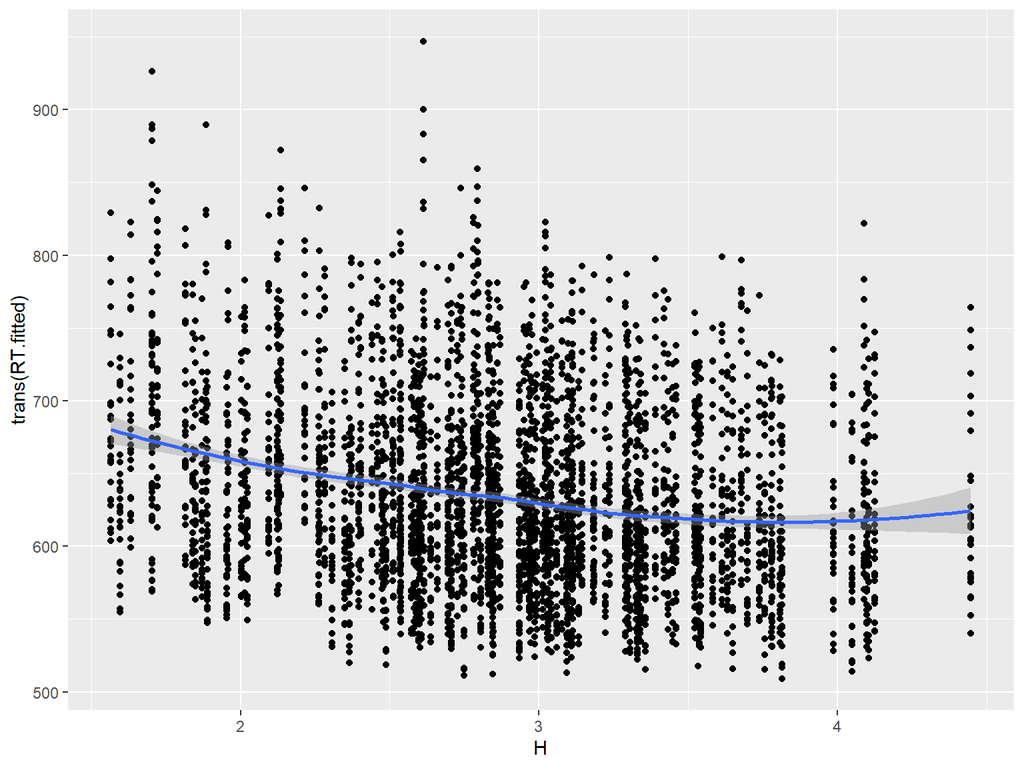

```r
ggplot(dat, aes(x=H, y=trans(RT.fitted))) +
  geom_point() +
  geom_smooth(method = "loess", se = TRUE)
```

```r
ggsave("H.lmerY1.jpg", width = 5, height = 5)
```